# Yeast data: cell ordering

Kushal K Dey

November 10, 2015

## Background

In this script, we apply the cellcycleR method on the synchronized cell experiment in yeast in Botstein [paper](http://www.ncbi.nlm.nih.gov/pmc/articles/PMC25624/). The data was collected from [Yeast Protein Database](http://quest7.proteome.com/YPDhome.html). The main motivation was to see if the sinusoidal like trends in Figure 1 in the paper can be replicated using the cellcycleR mechanism. Botstein’s group wrote another methods [paper](http://www.pnas.org/content/97/18/10101.full) where they showed the two eigenegenes to correspond to a sine wave and a cos wave with same phase shift (Check Figs 1 and 3). These were the prior results from their studies that we wanted to validate using cellcycleR.

We here considered only the cdc15 and cdc28 cell lines.

```r
library(qtlcharts)
library(CountClust)
library(parallel)
library(cellcycleR)
library(data.table)
library(binhf)
library(vioplot)
library(limma)
```

## cdc15 Data analysis

### Data exploration

The main concern in analyzing this data was the presence of NA values and how to deal with it. There were many genes which had NA values at different cell time points reported. To get around this problem, I substituted every non-leading NA value with the last non-NA value observed. In case of leading NAs, I replaced them by the first non-NA value. Since the cells were already ordered by time, this seemed the most obvious thing to do.

```r
setwd("/Users/kushal/Documents/singleCell-method/project/analysis/")
data <- read.table("../data/Botstein_data/botstein_cdc.txt", sep="\t", header=TRUE, fill=TRUE);
cdc_data <- data[,grep("cdc15",colnames(data))];

fillNAgaps <- function(x, firstBack=FALSE) {
    ## NA's in a vector or factor are replaced with last non-NA values
    ## If firstBack is TRUE, it will fill in leading NA's with the first
    ## non-NA value. If FALSE, it will not change leading NA's.

    # If it's a factor, store the level labels and convert to integer
    lvls <- NULL
    if (is.factor(x)) {
        lvls <- levels(x)
        x    <- as.integer(x)
    }

    goodIdx <- !is.na(x)

    # These are the non-NA values from x only
    # Add a leading NA or take the first good value, depending on firstBack
    if (firstBack)   goodVals <- c(x[goodIdx][1], x[goodIdx])
    else             goodVals <- c(NA,            x[goodIdx])

    # Fill the indices of the output vector with the indices pulled from
    # these offsets of goodVals. Add 1 to avoid indexing to zero.
    fillIdx <- cumsum(goodIdx)+1

    x <- goodVals[fillIdx]

    # If it was originally a factor, convert it back
    if (!is.null(lvls)) {
        x <- factor(x, levels=seq_along(lvls), labels=lvls)
    }

    x
}

cdc_data <- cdc_data[rowSums(is.na(cdc_data)) < (dim(cdc_data)[2] - 4),];
cdc_data_mod <- t(apply(cdc_data, 1, function(x) fillNAgaps(x, firstBack = TRUE)));

cycle_data <- t(cdc_data_mod);
dim(cycle_data)
```

```
## [1]   24 5799
```

We mean center the genes and scale them by the standard deviation.

```r
cycle_data_norm <- apply(cycle_data,2,function(x)  return (x-mean(x))/sd(x))
celltime_levels <- 100;
cycle_data_norm <- cycle_data_norm[, -which(colSums(cycle_data_norm)==0)]

dim(cycle_data_norm)
```

```
## [1]   24 5733
```

### cellcycleR application on Yeast cdc 15 data

```r
out <- cell_ordering_class(cycle_data_norm, celltime_levels = 100, num_iter=100, save_path="../rdas/cell_order_yeast_cdc15.rda")
```

We ran the method above once already (took around 5 minutes) and now we just load the output.

```r
out <- get(load(file="../rdas/cell_order_yeast_cdc15.rda"));
cell_order_full <- cell_ordering_full(out$signal_intensity, dim(cycle_data_norm)[2])
```

We look at the plots of the amplitudes, phases and the non signal variation of the genes.

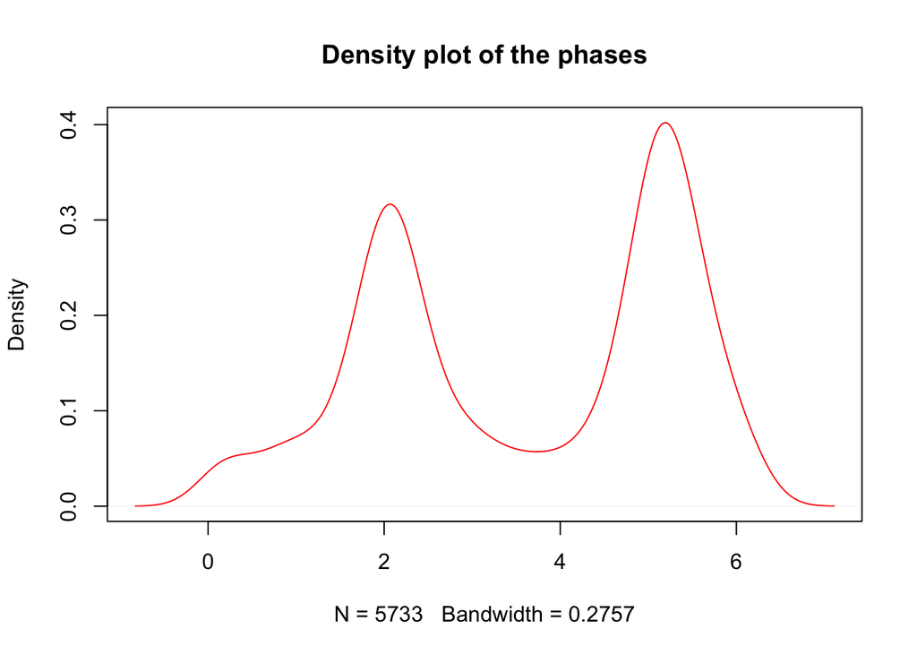

```r
amp_genes <- out$amp;
sd_genes <- out$sigma;
phi_genes <- out$phi;

plot(density(phi_genes), col="red", main="Density plot of the phases")
```

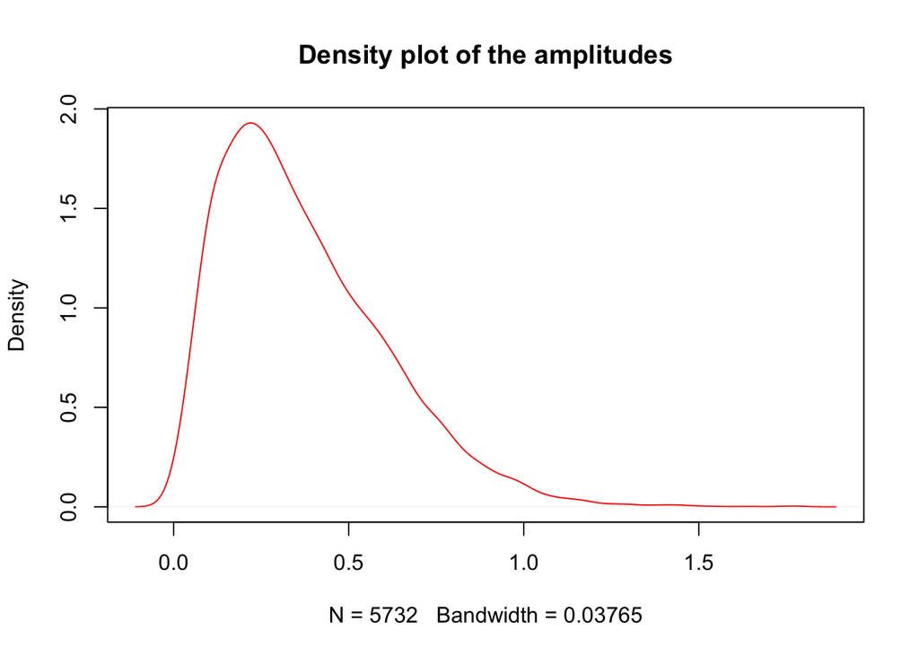

```r
plot(density(amp_genes[-which.max(amp_genes)]), col="red", main="Density plot of the amplitudes")
```

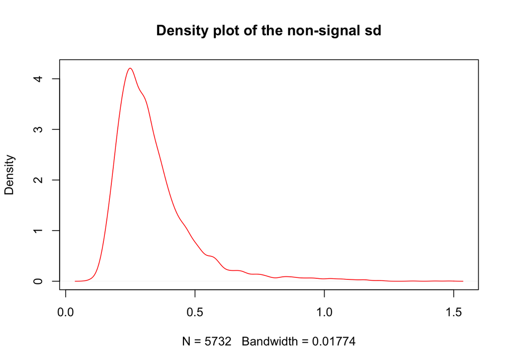

```r
plot(density(sd_genes[-which.max(sd_genes)]), col="red", main="Density plot of the non-signal sd")
```

We extract the genes with high SNR - these are more likely to be sinusoidal.

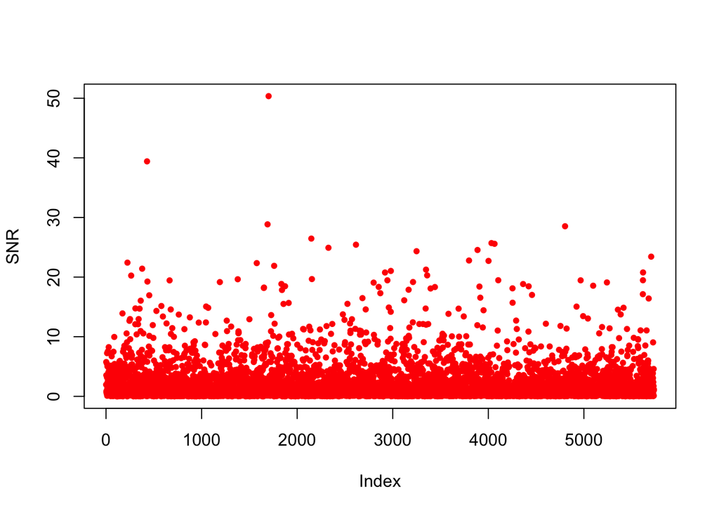

```r
ESS <- amp_genes^2; RSS <- sd_genes^2

SNR <- ESS/RSS;

plot(SNR, col="red", pch=20, lwd=1)
```

```r
top_genes <- which(SNR > 10);
```

Next we plot the qtlcharts for these top sinusoidal genes and see if their patterns are indeed sinusoidal or not.

First we present the data in the order of the columns (the cell times ordering reported by the authors).

```r
iplotCurves(t(cycle_data_norm[,top_genes]))
```

```
## Set screen size to height=700 x width=1000
```

[interactive chart not shown]

Now, the re-ordered cell times by cellcycleR (which do not match with the order of cell times given) are

```r
iplotCurves(t(cycle_data_norm[order(cell_order_full),top_genes]))
```

[interactive chart not shown]

## cdc 28 Data analysis

### Data exploration

We repeat the same exploration as for cdc15 data.

```r
data <- read.table("../data/Botstein_data/botstein_cdc.txt", sep="\t", header=TRUE, fill=TRUE);
cdc_data <- data[,grep("cdc28",colnames(data))];
cdc_data <- cdc_data[rowSums(is.na(cdc_data)) < (dim(cdc_data)[2] - 4),];
cdc_data_mod <- t(apply(cdc_data, 1, function(x) fillNAgaps(x, firstBack = TRUE)));

cycle_data <- t(cdc_data_mod);

cycle_data_norm <- apply(cycle_data,2,function(x)  return (x-mean(x))/sd(x))
celltime_levels <- 100;
cycle_data_norm <- cycle_data_norm[, -which(colSums(cycle_data_norm)==0)]
```

### Applying cellcycleR on cdc28 data

```r
out <- cell_ordering_class(cycle_data_norm, celltime_levels = 100, num_iter=100, save_path="../rdas/cell_order_yeast_cdc28.rda")
```

We ran the method above once already (took around 5 minutes) and now we just load the output.

```r
out <- get(load(file="../rdas/cell_order_yeast_cdc28.rda"));
cell_order_full <- cell_ordering_full(out$signal_intensity, dim(cycle_data_norm)[2])
```

We look at the plots of the amplitudes, phases and the non signal variation of the genes.

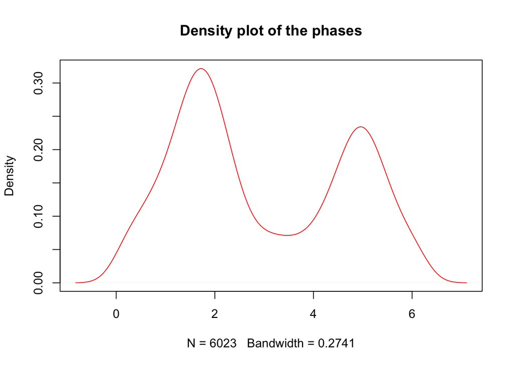

```r
amp_genes <- out$amp;
sd_genes <- out$sigma;
phi_genes <- out$phi;

plot(density(phi_genes), col="red", main="Density plot of the phases")
```

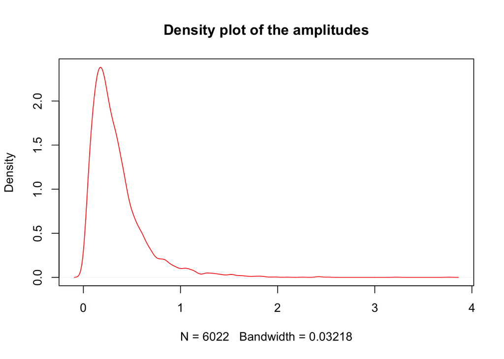

```r
plot(density(amp_genes[-which.max(amp_genes)]), col="red", main="Density plot of the amplitudes")
```

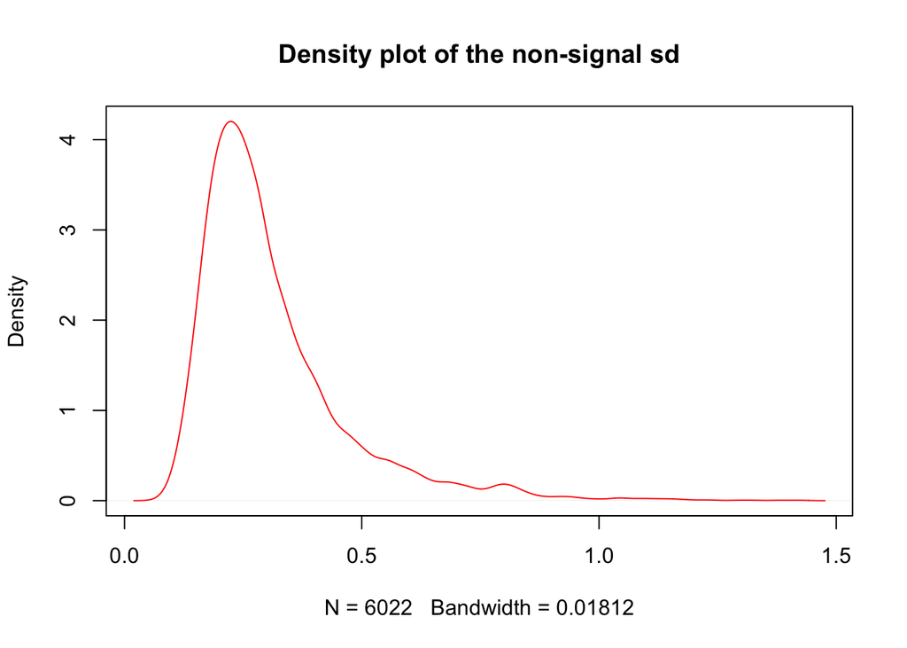

```r
plot(density(sd_genes[-which.max(sd_genes)]), col="red", main="Density plot of the non-signal sd")
```

We extract the genes with high SNR - these are more likely to be sinusoidal.

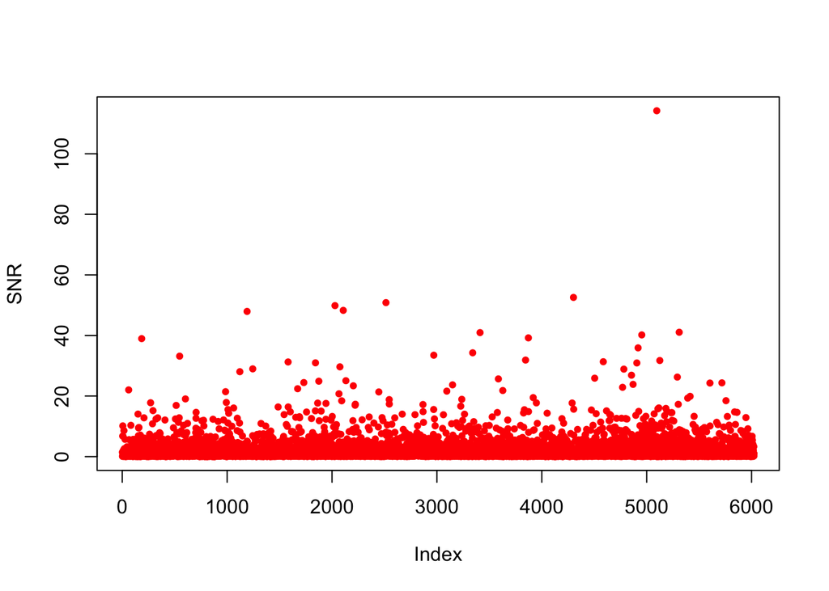

```r
ESS <- amp_genes^2; RSS <- sd_genes^2

SNR <- ESS/RSS;

plot(SNR, col="red", pch=20, lwd=1)
```

```r
top_genes <- which(SNR > 10);
```

Next we plot the qtlcharts for these top sinusoidal genes and see if their patterns are indeed sinusoidal or not.

First we present the data in the order of the columns (sorted by time)

```r
iplotCurves(t(cycle_data_norm[,top_genes]))
```

[interactive chart not shown]

Now, the re-ordered cell times (which do not match with the order of cell times given) are

```r
iplotCurves(t(cycle_data_norm[order(cell_order_full),top_genes]))
```

[interactive chart not shown]

## Final Thoughts

The cellcycleR method seemed to pick out two main phase peaks and the qtlcharts showed the phases to be complementary. This is encouraging because the eigengenes mainly showed 2 patterns, which are very close to what we get.